# gatrs version 0.2.0

“2017-08-22 09:02:40 PDT”

# 1 Introduction

For questions or corrections, please contact Gail Gong at gailgongster@gmail.com

`gstir` is an acronym for “Genetic Significance Tests in Relatives”

The main function of this package `gatrs` calculates the p-values of a family of statistics that test the association between a specified set of $M$ genetic markers, called target markers, and a binary trait. These statistics include three “basic” statistics–the squared burden statistic $Q_B$, the linear kernel (SKAT) statistic $Q_S$, and a new case-based kernel statistic $Q_C$–as well as an ensemble of four statistics $Q_{BS}$, $Q_{BC}$, $Q_{SC}$, $Q_{BSC}$ that optimize linear combinations of the three basic statistics. All seven statistics are summarized in Table 1 of the manuscript.

The test statistics use observations on a number $N$ of people, or subjects, who are sampled based on their unaffected/affected status of a binary trait such as prostate cancer, $y_n = 1(n\text{-th subject is affected} )$. Also the calculations require a user-specified trait probability $(\text{e_y})_n$ (for example the predicted value of $y_n$ from a logistic regression on nongenetic covariates and principle components of ancestry), and a row vector of genotypes (either the dosage or carriage of the minor allele) $g_n = (g_{n1}, \cdots, g_{nM})$ at the $M$ target markers. Define the genotype matrix of target markers, or more briefly, the “genotype matrix” $G$ to be the $N \times M$ matrix whose $(n,m)$-th component is the genotype of the $n$-th subject at the $m$-th target marker)

The test statistics take into account covariances of the elements in $G$. For pairwise covariances among the $M$ markers (summarized by $\Gamma$ in the manuscript) our calculations use the empirical covariance matrix of $G$. To account for pairwise covariances among the subjects, we require the user to provide a $\Psi$ matrix consisting of interpersonal genotype correlation coefficients (described in the manuscript by the same notation).

Obtaining the p-values of the optimized statistics further requires resampling from sets of markers located throughout the human genome. We require $M$ sampling sets, one for each target marker. The sampling set for the $m$-th target marker requires markers whose minor allele frequencies match closely with that of its target marker. Also the sampling sets should be independent of the target markers as well as markers known to be associated with the binary trait. The gatrs package can create these sampling sets provided the user supplies the following two items: (1) A data set containing genotypes of the $N$ subjects at a large number of markers or snps (in addition to the target markers) throughout the human genome. (In the analysis of the prostate data in the manuscript, we obtained `126702` snps which we feel is a large enough number.) (2) A data set containing the locations of markers associated with the binary trait.

The creation of the sampling sets also uses hotspots from “A Fine-Scale Map of Recombination Rates and Hotspots Across the Human Genome”, Myers, Simon;Bottolo, Leonardo;Freeman, Colin;McVean, Gil;Donnelly, Peter Science; Oct 14, 2005; 310, 5746; ProQuest Research Library, pg. 321. `gatrs` has translated the base-pair positions of the hotspots from this reference to Build hg38/GRCh38

TOP

# 2 Installing `gatrs`

If you have not yet installed R, download the latest version (at least 3.2.4) for your operating system at:

http://www.r-project.org

Run the R application. To install the `gatrs` package, enter the following lines of code to the R prompt:

```
install.packages("devtools")
library(devtools)
install_github("gailg/gatrs")
if("gatrs" %in% rownames(installed.packages())){
  print("gatrs installed successfully--you are good to go!")
} else {
  print("something went wrong--ask for help")
}
```

If your installation was successful, you should see the message

```
[1] "gatrs installed successfully--you are good to go!"
```

TOP

# 3 Data required

The function `gatrs` requires quite large data, and typically, you would organize your data in Plink.(http://pngu.mgh.harvard.edu/~purcell/plink/). We assume that you can bring your data into R and create the following data sets.

## 3.1 `bim`

A `data.frame` containing (at least) the three columns `chromosome`, `snp`, `bp` and $L$ rows corresponding to a very large number of $L$ markers. These markers include the target markers and those used to build the sampling sets. The `l`-th row of `bim` summarizes the `l`-th marker and corresponds to the `l`-th column of `genotype`. For each row, `chromosome` is an integer between `1` and `22` (other integers may be included, but only chromosomes `1` through `22` will be used), `snp` is a character naming the marker, and `bp` is the position (bp) of the marker. (Because the `gatrs` data set `hotspot` is in Build hg38/GRCh38, `bp` must also be expressed in Build hg38/GRCh38.)

## 3.2 `genotype`

A matrix with $N$ rows and $L$ columns, whose $(n,l)$-th element records either the number ($0$, $1$ or $2$) of minor alleles of snp $l$ found in the $n$-th subject or an indicator ($0$ or $1$) for the $n$-th person carrying at least one minor allele at snp $l$. The $l$-th column of `genotype` corresponds to the `l`-th row of `bim`. The matrix `genotype` could be gotten by reading in the `.bed` file from plink after massaging genotype information into either dosage or carriage. (Distinguish `genotype` here the matrix containing target markers AND sampling set markers with the “genotype matrix” $G$, the matrix containing just the target markers.)

## 3.3 `target_markers`

A vector that is a subset of the column `bim$snp`. This vector names the target markers.

## 3.4 `fam`

A `data.frame` containing $N$ rows and at least the two columns $y$ and $\text{e_y}$ where $y_n = 1(n \text{-th person is affected} )$ and $\text{e_y}_n$ is a trait probability, the predicted value of $y_n$ based on nongenetic covariates and possibly principal components of ancestry. After we saw that principal conponents of ancestry were insignificant, we performed a logistic regression of $y$ on (1) age, (2) membership in family or case/control data, and (3) their interaction, and used $\text{e_y}$ to be the fitted values of the logistic regression.

## 3.5 `Psi` = $\Psi$

A matrix with $N$ rows and $N$ columns. $\Psi_{n_1, n_2}$ is the correlation for the genotype at one marker between the $n_1$-th and $n_2$-th subjects. $\Psi$ can be estimated from known family pedigree structures and/or from the subjects’ genotypes at markers independent of those in the target set. The diagonal elements are all unity and two people known to be non-identical-twin full sibs and who have parents known to be completely unrelated have correlation $1/2$.

## 3.6 `exclusion_region`

A `data.frame` with one or several rows of the three columns `chromosome`, `begin`, and `end`. Each row of this `data.frame` reflects one contiguous genomic region known to be associated with the binary trait and therefore a region used by `gatrs` when creating the sampling sets. The column `chromosome` is an integer between `1` and `22` naming which chromosome the region lies, and `begin` and `end` describe its beginning and ending positions (bp). If the region consists of a single marker, then `begin` and `end` are both equal to the position of this marker. `begin` and `end` must to be expressed in Build hg38/GRCh38 for the same reason the column `bp` in `bim` must be expressed in Build hg38/GRCh38.

## 3.7 `hotspot`

The `gatrs` package provides this data set for your convenience. This file contains (at least) the columns `chromosome` and `center`; `chromosome` describes the number of the chromosome (`1:22`), and `center` describes the location of hotspots.

TOP

# 4 An example data set

The package `gatrs` provides an example data set which I will use to illustrate how to use the package. You can access this example data with the following commands.

```r
library(gatrs)
bim = alternative_example$bim
exclusion_region = alternative_example$exclusion_region
fam = alternative_example$fam
genotype = alternative_example$genotype
target_markers = alternative_example$target_markers[3:5]
Psi = alternative_example$Psi
```

## 4.1 `bim` has 24509 rows and includes the columns `chromosome`, `snp`, and `bp`

```r
str(bim)
```

```
## 'data.frame':    24509 obs. of  3 variables:
##  $ chromosome: int  1 1 1 1 1 1 1 1 1 1 ...
##  $ snp       : chr  "exm53" "exm94" "exm222" "exm269" ...
##  $ bp        : int  865665 874501 880160 881918 891393 899789 902088 908944 909253 909309 ...
```

## 4.2 `genotype` has 200 rows and 24509 columns

I chose a relatively small number of columns to keep the example small.

```r
str(genotype)
```

```
##  int [1:200, 1:24509] 0 0 0 0 0 0 0 1 0 0 ...
##  - attr(*, "dimnames")=List of 2
##   ..$ : chr [1:200] "1" "2" "3" "4" ...
##   ..$ : chr [1:24509] "exm53" "exm94" "exm222" "exm269" ...
```

The column names of `genotype` must match `bim$snp`:

```r
all(colnames(genotype) == bim$snp)
```

```
## [1] TRUE
```

## 4.3 `target_markers` is a character vector containing 3 names

```r
str(target_markers)
```

```
##  chr [1:3] "exm1061853" "exm1061861" "exm1061863"
```

The elements in `target_markers` must be included in `bim$snp`

```r
all(target_markers %in% bim$snp)
```

```
## [1] TRUE
```

## 4.4 `fam` has 200 rows and includes the columns `y` and `e_y`

```r
str(fam)
```

```
## 'data.frame':    200 obs. of  3 variables:
##  $ id : int  1 2 3 4 5 6 7 8 9 10 ...
##  $ y  : int  0 0 1 0 1 1 1 1 1 0 ...
##  $ e_y: num  0.838 0.898 0.82 0.675 0.944 ...
```

## 4.5 `Psi` is a 200 $\times$ 200 square matrix

```r
str(Psi)
```

```
##  num [1:200, 1:200] 1 0.5 0 0 0 0 0 0 0 0 ...
```

The following figure reflects the fact that the first `100` people are made up of `50` sib pairs, and the last `100` people` are independent.

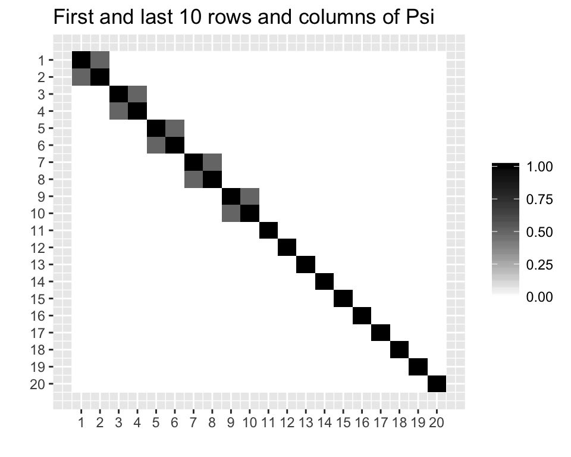

```r
NNN = nrow(fam)
first_ten = 1:10
last_ten = NNN - (9:0)
matrix_image_fn(Psi[c(first_ten, last_ten), c(first_ten, last_ten)],
                main = "First and last 10 rows and columns of Psi")
```

```r
str(exclusion_region)
```

```
## 'data.frame':    115 obs. of  3 variables:
##  $ chromosome: num  1 1 1 1 1 2 2 2 2 2 ...
##  $ begin     : int  10496040 150685811 154861707 204549714 205788696 9977740 10570604 20688505 43326810 62904596 ...
##  $ end       : int  10496040 150685811 154861707 204549714 205788696 9977740 10570604 20688505 43326810 62904596 ...
```

## 4.7 `hotspot` is available as soon as you enter `gatrs`:

```r
str(hotspot)
```

```
## 'data.frame':    25657 obs. of  4 variables:
##  $ chromosome: int  1 1 1 1 1 1 1 1 1 1 ...
##  $ center    : num  949794 1725398 2021339 2102281 2282281 ...
##  $ start     : int  635391 1722898 1950897 2099781 2273781 2387781 2462781 2835085 2881085 2956085 ...
##  $ end       : int  1264196 1727898 2091781 2104781 2290781 2437781 2493781 2841085 2902085 2971086 ...
```

# 5 Check that your genotype matrix has full rank

`genotype_target_markers` is the genotype matrix.

```r
library(Matrix)
genotype_target_markers = genotype[, target_markers]
list(target_markers = target_markers,
     rank = as.numeric(rankMatrix( genotype_target_markers)))
```

```
## $target_markers
## [1] "exm1061853" "exm1061861" "exm1061863"
##
## $rank
## [1] 3
```

# 6 gatrs-sampling-set

Once you have your data in R, and you have checked that your genotype matrix has full rank, use the function `gatrs_sampling_set` to create your sampling sets.

## 6.1 A description of how `gatrs_sampling_set` builds the sampling sets

Each column in `genotype` corresponds to a row in `bim`, and both correspond to a marker or snp. After removing the target markers, we want to form, from the remaining snps, $M$ sampling sets, one for each of the target markers. Recall that the two conditions we require of the sampling sets are *the matching requirement*: the snps in the sampling set for a target marker has minor allele frequencies that match closely with that of the target marker and *the independence requirement*: Any snp from any sampling set is statistically independent of the target markers and any marker known to be associated with the binary trait.

We assume that hotspots from Myers et.al. cut the genome into independent segments, and so snps residing within two consecutive hotspots are independent of snps residing within another two consecutive hotspots. Defining a segment to be a set of snps that all lie within two consecutive hotspots, we obtain a (large) set of independent segments. To satisfy the *the independence requirement* we need only remove any segments that contain any target markers or any markers defined by the `exclusion_region` data set.

Of the markers residing in the remaining segments, we calculate their empirical minor allele frequencies and say that a marker’s frequency matches the minor allele frequency $p_m$ of the $m$-th target marker if it is within $p_m \times \big[1 -$ `epsilon_on_log_scale` $, 1 +$ `epsilon_on_log_scale` $\big]$. If the number of markers satisfying the matching requirement exceeds `1000`, `gatrs` randomly chooses `1000`.

## 6.2 The arguments of `gatrs_sampling_set`

The following is the function header of `gatrs_sampling_set` showing which arguments are needed and in which order.

```
gatrs_sampling_set(
  bim,
  genotype,
  target_markers,
  exclusion_region,
  hotspot,
  epsilon_on_log_scale = 0.02
)
```

### 6.2.1 `bim`, `genotype`, `target_markers`, `exclusion_region`, and `hotspot`

These objects have already been discussed in An example data set.

### 6.2.2 `epsilon_on_log_scale`

A positive small real number used to parametrize the matching

When creating the $m$-th sampling set for target marker with minor allele frequency $\pi_m$, only those markers whose minor allele frequencies falling within the interval $\pi_m \times \big[1 -$ `epsilon_on_log_scale` $, 1 +$ `epsilon_on_log_scale` $\big]$ can be included in the sampling set.

## 6.3 Example calls to `gatrs_sampling_set`

```r
set.seed(2)
sampling_set = gatrs_sampling_set(
  bim,
  genotype,
  target_markers,
  exclusion_region = NULL,
  hotspot,
  epsilon_on_log_scale = 0.02)
print(sampling_set)
```

```
## $sampling_set_report
##      min p_target    max set_size
## 1 0.0750   0.0750 0.0750      588
## 2 0.0250   0.0250 0.0250      658
## 3 0.0675   0.0675 0.0675      663
##
## $minimum_sampling_set_size
## [1] 588
```

```r
set.seed(2)
head(exclusion_region)
```

```
##    chromosome     begin       end
## 1           1  10496040  10496040
## 2           1 150685811 150685811
## 3           1 154861707 154861707
## 4           1 204549714 204549714
## 5           1 205788696 205788696
## 11          2   9977740   9977740
```

```r
exclusion_region[exclusion_region$chromosome == 19, ]
```

```
##     chromosome    begin      end
## 114         19 38244973 50861367
## 115         19 54293995 54293995
```

```r
sampling_set = gatrs_sampling_set(
  bim,
  genotype,
  target_markers,
  exclusion_region = exclusion_region,
  hotspot,
  epsilon_on_log_scale = 0.02)
print(sampling_set)
```

```
## $sampling_set_report
##      min p_target    max set_size
## 1 0.0750   0.0750 0.0750      480
## 2 0.0250   0.0250 0.0250      543
## 3 0.0675   0.0675 0.0675      536
##
## $minimum_sampling_set_size
## [1] 480
```

TOP

# 7 `gatrs`

## 7.1 A description of `gatrs`

`gatrs` calculates the p-values of the following seven statistics: the squared burden $Q_B$, the SKAT $Q_S$, the case based $Q_C$, and optimal linear combinations $Q_{BS}$, $Q_{BC}$, $Q_{SC}$, $Q_{BSC}$. The p-value of any linear combination of the basic statistics $Q_B$, $Q_S$, and $Q_C$ can be calculated using the `davies` function from the `CompQuadForm` package, but the theory no longer applies when a statistic is an optimal one in a universe of linear combinations. We obtain the null distribution of these optimal statistics by resorting to an innovative kind of simulation, which we call *Genome Resampling*.

Recall our notation: $G$ is the $N \times M$ genotype matrix of target markers, $y$ is the $N$-vector indicator for disease, and $\text{e_y}$ is an $N$-vector of trait probabilities. Any linear combination of the basic statistics can be written as a quadratic form $Q(\alpha) = Z^T A(\alpha) Z$ where $Z$ is a linear function of the two vectors $W G y$ and $W G p$, $W$ is a diagonal matrix whose nonzero elements weight the target markers, $A(\alpha)$ is a square matrix that does not depend on $G$, and $\alpha$ are the coeffients of the linear combination of basic statistics. $Z$ is a multivariate normal vector when $N$ is large, with mean $\mu$ and covariance matrix $\Sigma$ which depend on the first two moments of $G$. For a fixed value of $\alpha$, the `davies` function can calculate the p-value for $Q(\alpha)$. Each optimal statistic $Q_{BS}$, $Q_{BC}$, $Q_{SC}$, $Q_{BSC}$ is a monotonoic (decreasing) function, $-\text{log}_{10}$, of the smallest p-value of $Q(\alpha)$ over a set of values of $\alpha$.

To run a simulation to get the null distribution of an optimal statistic $Q_{\text{optimal}}$, we need to obtain simulated observations of a large number $S$ of replications of the genotype matrix $\Big\{\tilde{G}^{(1)}, \cdots, \tilde{G}^{(S)}\Big\}$. On the $s$-th simulated genotype matrix $\tilde{G}_s$, we calculate $Q(\alpha)$ over the set of values of $\alpha$ and obtain the optimal one $Q^{(s)}_{\text{optimal}}$. The p-value of $Q_{\text{optimal}}$ is the proportion of $\Big\{ Q^{(1)}_{\text{optimal}}, \cdots, Q^{(S)}_{\text{optimal}} \Big\}$ that exceed $Q_{\text{optimal}}$.

The question becomes how to generate each $\tilde{G}^{(s)}$ so that it has the same distribution as the observed genotype matrix $G$ conditional on its following the null model? We propose *Genome Resampling*: Form $\tilde{G}^{(s)}$ by sampling one column from each sampling set created according to Section gatrs-sampling-set. We report in the manuscript simulation studies that show that under different family designs and different degrees of correlations of the target markers, it is not necessary to match column covariances of $\tilde{G}^{(s)}$ to those of the oberved genotype matrix of target markers for this approach to still give good test sizes. We believe it is possible to have some nonzero correlations between the sampled markers, but since there can be such a wide variety of possible correlations if we allowed them, we chose to limit our simulation studies and therefore our prescription to independent sampling sets. We do however insist on matching column means.

## 7.2 The arguments of `gatrs`

The following is the function header of `gatrs` showing which arguments are needed and in which order.

```
gatrs(fam, Psi, sampling_set, N_sim_reps, weights)
```

### 7.2.1 `fam` and `Psi`

These objects have already been discussed in An example data set.

### 7.2.2 `sampling_set`

This object is the result of `gatrs_sampling_set` and you may follow the example from gatrs-sampling-set

### 7.2.4 `weights`

TOP

## 7.3 Example calls to `gatrs`

These take some time to run. If you have larger numbers $N$ of people or larger numbers $M$ of target markers, run times will increase.

```r
start = Sys.time()
set.seed(1)
gatrs(fam, Psi, sampling_set, N_sim_reps = 1000, weights = c(5, 3, 2))
elapsed_time = Sys.time() - start
paste("1000 sim reps required",
      round(elapsed_time, 1), attributes(elapsed_time)$units)
```

[output not shown]

```r
start = Sys.time()
set.seed(1)
gatrs(fam, Psi, sampling_set, N_sim_reps = 2000)
elapsed_time = Sys.time() - start
paste("2000 sim reps required",
      round(elapsed_time, 1), attributes(elapsed_time)$units)
```

[output not shown]

# 8 All the code in one place

```r
library(gatrs)

# Preparing the data
bim = alternative_example$bim
exclusion_region = alternative_example$exclusion_region
fam = alternative_example$fam
genotype = alternative_example$genotype
target_markers = alternative_example$target_markers[3:5]
Psi = alternative_example$Psi
NNN = nrow(fam)
first_ten = 1:10
last_ten = NNN - (9:0)
matrix_image_fn(Psi[c(first_ten, last_ten), c(first_ten, last_ten)],
                main = "First and last 10 rows and columns of Psi")

# Checking the rank of the genotype_target_markers matrix
library(Matrix)
genotype_target_markers = genotype[, target_markers]
list(target_markers = target_markers,
     rank = as.numeric(rankMatrix( genotype_target_markers)))

# Creating the sampling_set
set.seed(2)
sampling_set = gatrs_sampling_set(
  bim,
  genotype,
  target_markers,
  exclusion_region = NULL,
  hotspot,
  epsilon_on_log_scale = 0.02)
print(sampling_set)

set.seed(2)
sampling_set = gatrs_sampling_set(
  bim,
  genotype,
  target_markers,
  exclusion_region = exclusion_region,
  hotspot,
  epsilon_on_log_scale = 0.02)
print(sampling_set)

# Calling gatrs with N_sim_reps = 1000 and 2000
start = Sys.time()
gatrs(fam, Psi, sampling_set, N_sim_reps = 1000)
elapsed_time = Sys.time() - start
paste("1000 sim reps required",
      round(elapsed_time, 1), attributes(elapsed_time)$units)
start = Sys.time()
gatrs(fam, Psi, sampling_set, N_sim_reps = 2000)
elapsed_time = Sys.time() - start
paste("2000 sim reps required",
      round(elapsed_time, 1), attributes(elapsed_time)$units)
```